# PAGe: Phase-Aligned Gated Epidemic Forecasting

**At A Glance**

- `$M_0$` detects ignition prospectively from raw surveillance data.
- `$M_1$` aligns the current season to historical templates and estimates epidemic phase and peak timing.
- `$M_2$` consumes alignment-derived covariates plus real-time features to forecast 1- and 2-week-ahead positivity.
- The linked documents contain the derivations and historical tuning analyses; `deployment-workflow.qmd` is the canonical governed release workflow. A rendered document is not evidence that a private-data run completed.

## 1 Notation

Let $s = 1,\dots,S$ index influenza seasons and let $w$ denote the within-season flu-week number. For each season-week $(s,w)$, define:

- $x_{s,w}$: number of influenza-positive tests (code column `y`)
- $n_{s,w}$: number of tests performed (code column `N`)
- $p_{s,w} = x_{s,w} / n_{s,w}$: observed weekly positivity (code column `p`)
- $\pi_{s,w}$: underlying probability of positivity (the quantity modelled/forecast)

Several week indices are kept in the data:

- `week`: MMWR **epidemiologic week-of-year** from surveillance data.
- `weekS`: **surveillance-week index** (season starts at MMWR week 35), for interpretation only.
- `weekF`: $w^f_{s,w}$, **flu-week index** (flu season starts at MMWR week `startWeek`; here 27).
- `iWeek`: $w^{(\mathrm{ign})}_s$, ignition week for season $s$ (manually labelled or estimated).
- `anchorWeek`: $w^{an}$, anchor week for alignment (median ignition week across seasons).
- `newWeek`: $w^a_{s,w}$, **aligned week index** after shifting $w^f_{s,w}$ so that $w^{(\mathrm{ign})}_s$ lines up at `anchorWeek` across seasons
- `peak`: $w^p_s$, week of the season’s epidemic peak (estimated by alignment).

Let $P(s,w)\in\{0,1\}$ be a phase indicator:
$$P(s,w)=
\begin{cases}
0, & \text{pre-ignition (pre-season)}\\
1, & \text{post-ignition (in-season)}
\end{cases}$$

The framework has 3 main components:

- **$M_0$ (Ignition detector):** using only information available up to week $w$, estimate whether the season has ignited ($P(s,w)=1$), estimate reference curve.
- **$M_1$ (Alignment):** shifts and stretches the estimated reference curve to fit the observed data, producing an estimate of the current epidemic phase and a rough forecast trajectory.
- **$M_2$ (Forecast model):** once ignition is detected and aligned, build forecast model and forecast $h$ weeks ahead:
  $$\pi_{s,w+h} \;=\; \Pr\!\big(\text{positive at } w+h \mid P(s,w)=1,\, M_1\big).$$

Primary forecasting targets are one- and two-week-ahead positivity $\pi_{s,w+1}$ and $\pi_{s,w+2}$. Raw surveillance data is converted to a within-season week index (`weekF`) starting at MMWR week 27. Each row is one season-week with columns `y` (positive tests), `N` (total tests), and `p = y/N`. Seasons with known data quality issues (`2020-21`, `2021-22`) are excluded.

## 2 $M_0$ – Ignition Detection

**Goal:** detect the start of the epidemic season in real time.

$M_0$ votes each week using four threshold-based gates (`cond_sum`, `cond_p`, `cond_prev`, `cond_inc`) capturing level, trend, cumulative burden, and sustained elevation from data available up to the current week only. Ignition fires when all four agree simultaneously within a tuned eligibility window. Gate thresholds are selected by LOSO grid search against known ignition weeks using a lexicographic objective: first minimise the number of seasons with adjusted detection error > 2 weeks, then minimise the maximum error across seasons, then minimise a composite score. Once ignition locks at $\hat{w}^{(\mathrm{ign})}_s$, the aligned coordinate system activates:

$$w^a_{s,w} = w^f_{s,w} - \hat{w}^{(\mathrm{ign})}_s + w^{an}.$$

**Key functions:** `tuneIgnitionGrid_M0v2()`, `detectIgnitionBySeason_M0v2()`, `run_ignition_weekly()`

**Full analysis:** `ignition_training.html`

## 3 $M_1$ – Curve Alignment

**Goal:** align observed epidemic curves to historical templates to continuously estimate peak timing.

After ignition, each week’s partial curve is aligned to each training season’s template in parallel using a 4-parameter dilation model ($\tau_w$, $\delta_w$, $a_w$, $b_w$). Template fits are ensemble-weighted by alignment quality (NLL) and slope similarity via softmax, yielding a continuously updated peak estimate. Once the peak is detected (`peak_passed == TRUE`), alignment freezes.

### 3.1 Reference curve estimation

Historical seasons are aligned to their manually-labelled ignition weeks ($w^{(\mathrm{ign})}_s$) at the median anchor $w^{an}$:

$$w^a_{s,w} = w^f_{s,w} - w^{(\mathrm{ign})}_s + w^{an}.$$

The factor-smooth (`"fs"`) method fits a GAM with `s(newWeek, season, bs="fs", xt=list(bs="cc"))` on logit-scale data, returning per-season curves `eta_mat` used for multi-template alignment.

**Key functions:** `flagIgnition()`, `alignIgnition()`, `estimateRef()`, `learn_alignment_hyperparams()`

**Full analysis:** `estimateRef.html`

### 3.2 Post-peak flag tuning

`tune_peak_detection()` selects `use_ci` and `buffer_weeks` to minimise detection delay with zero false positives.

**Full analysis:** `peak_detection_tuning.html`

### 3.3 Training

All $M_1$ hyperparameters are tuned by leave-one-season-out walk-forward evaluation (67-config grid across v5-v7): each fold re-estimates the reference curve excluding the held-out season, then walks forward week by week producing `params_df`. Peak MAE under Weibull weighting is the primary metric.

**Locked configuration in code:** `k_ref=25`, `temperature=0.25`, `shift=0`, `slope_window=6`, `slope_weight=8`. Historical sources report conflicting peak MAE values (including 1.338 and 1.275 weeks), but their private tuning artifacts are absent. Treat neither value as verified by this repository.

**Key functions:** `loso_walkforward()`, `tune_m1_alignment()`

**Full analysis:** `loso_walkforward.html`

### 3.4 Deployment

Each week `align_multi_template()` is called with frozen `ref`, `hyper`, `params`, and tuned ensemble parameters, returning `state` (`"pre_ignition"` / `"aligning"` / `"post_peak"`), peak estimate with CI, and aligned covariates for $M_2$.

**Key functions:** `run_alignment_prospective()`, `align_multi_template()`

## 4 $M_2$ – Forecast Model

**Goal:** forecast 1- and 2-week-ahead positivity using $M_1$ alignment outputs.

$M_2$ fits a joint binomial GAM for $h \in \{1,2\}$ on aligned-week space. Covariates from $M_1$ (`newWeek`, template backbone $z_{s,w}(\delta, Kr)$) are leakage-sensitive – they depend on $g_{\mathrm{ref}}$. Real-time covariates (EWMA state $z^{(\mathrm{ema})}_{s,w}$, slope $d1$, curvature $d2$) are computed from raw surveillance data and do not leak.

### 4.1 Training

Historical M2 hyperparameter evaluation uses LOSO folds and fold-specific M1 predictions. The recorded evaluation is conditional on globally selected M0 and M1 choices, so it is not fully nested validation of the entire pipeline.

**Current working incumbent.** The existing frozen `v16-corrected` kit used in the 2025-26 acceptance replay is the working baseline. Its private artifact is outside version control, so this records the operational specification without claiming to recover the original research artifact:

```
delta=0, Kr=1, k_f=4, k_e=2, k_n=0, k_r=0, k_de=0, k_sp=8
alpha_state=0.20, bias_alpha=0.05, bias_beta=0, lambda_w=0, w_floor=0.05
```

Mode: **frozen GAM** pre-trained on historical seasons + **Holt EMA bias correction** (level-only, `bias_alpha=0.05`, `bias_beta=0`) + an online season random effect estimated from post-ignition observations only. Weekly refitting is retained only as an explicit compatibility option. A coded default becomes deployable only through the governed promotion workflow.

**Key functions:** `nested_loso_build_fold()`, `m1_walkforward_multi()`, `nested_loso_m2_train()`, `nested_loso_m2_eval_frozen_bias()`, `prep_stage2_joint()`, `train_stage2_joint()`

**Full design:** `forecast_training.html`

### 4.2 Deployment

The coded deployment path uses a frozen GAM fit on the authorized training seasons. Each week after ignition, a Holt EMA bias corrector and online season random effect are updated sequentially, then the frozen GAM forecasts 1- and 2-weeks ahead. The fit becomes a deployment artifact only after the governed acceptance, fixed-spec refresh, and immutable promotion sequence.

**Key functions:** `run_m2_forecast()` (mode=`"frozen"`), `m2_predict_one()`, `load_promoted_kit()` for governed registry artifacts, and `load_prospective_kit()` for strict component-level kit loading.

### 4.3 Retrospective fit-back

Before a live season, $M_2$ may be fit on the authorized historical seasons using the selected specification and production reference curve (`nested_loso_refit_best()`). The resulting fit-back is a descriptive training diagnostic, not prospective validation: each historical trajectory comes from a model fit that includes that season, and the specification was selected conditional on prior M0/M1 choices.

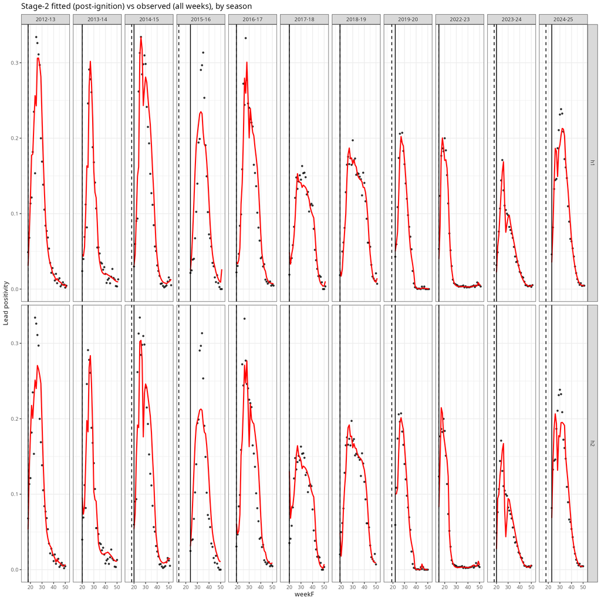

**Full code:** `forecast_training.html §Fit-back`

## 5 Training and deployment sequence

Offline training is guarded stage by stage. Within each live week, $M_1$ aligns and, for a post-ignition state, $M_2$ forecasts using the frozen GAM and updates the adaptive Holt bias corrector. Full runtime implementation: `prospective_deployment.html`.

| Step | What | Gate | When |
| --- | --- | --- | --- |
| 1 | Declare training, exclusion, holdout, and application seasons | `validate_season_selection()` | Offline, once per development cycle |
| 2 | Tune, validate, fit, and freeze $M_0$ ignition | Finite selected metric, complete folds, frozen artifact | Offline |
| 3 | Tune, validate, fit, and freeze $M_1$ alignment | Frozen matching $M_0$, evaluable seasons, finite selected metric | Offline |
| 4 | Tune, validate, fit, and freeze $M_2$ forecast | Frozen matching $M_0/M_1$, complete finite candidate selection | Offline |
| 5 | Assemble and validate the kit | All stages frozen with matching selection and upstream identities | Offline, before acceptance |
| 6 | Accept, fixed-spec refresh, and register | Hash-bound governed release chain | Offline, before deployment |
| **7** | **Weekly: $M_0$ detects -> $M_1$ aligns -> $M_2$ forecasts** | **Validated registered kit** | **Online, every week** |

### 5.1 Training and promotion governance

The guarded low-level API is `tune_*() -> validate_*_tuning() -> fit_*() -> freeze_*()` for each stage, followed by `assemble_kit()` and `validate_page_kit()`. A downstream stage rejects an unfrozen, selection-mismatched, or identity-mismatched upstream artifact.

`train_pipeline(mode="refresh")` is a compatibility orchestrator that refits the locked production specification through the guarded lifecycle. `mode="retune"` retunes M0, M1, and M2 through the same guarded sequence. Its bounded M2 grid is seeded by compatible previous results, always retains the v16 incumbent, preserves diverse finalists, adds local neighbors, and expands boundaries reached by the previous winner. Finalists are selected by minimum Bernoulli NLL by default; `selection_method="one_se"` instead chooses the simplest candidate within one standard error of the best NLL, while `"pareto"` uses NLL, worst-horizon MAE, and worst-phase MAE before its deterministic tie order. These are three explicit user options. Optional staged racing removes only candidates whose uncertainty intervals clearly lose, and every survivor is still evaluated with full nested LOSO.

Grid adequacy is checked after every valid tuning round. A winning value at a tested minimum or maximum normally triggers one controlled expansion using the adjacent observed spacing, while retaining the incumbent, winner, and local neighbors. A boundary may instead be accepted when it is a meaningful null (for example, an optional smooth set to zero) or a hard valid constraint. Every decision is recorded; a computational cap leaves the boundary unresolved rather than proving an optimum. See the tuning playbook.

Retuning and holdout evaluation are separated. Retuning must finish before `2025-26` is examined. A change to the grid, model, thresholds, or correction rule after viewing the holdout starts a new development cycle and does not inherit the earlier acceptance result.

The governed release path has four phases: replay frozen candidate and incumbent kits that both exclude `2025-26`; preserve the locked gate decision as immutable evidence; perform a fixed-spec refresh that includes `2025-26` only after a pass; then create an immutable registry entry loaded through its verified deployment manifest. Failed or malformed evidence fails closed. See `deployment-workflow.qmd` for commands, manifest locations, `--preflight-only` checks, and no-overwrite behavior.

The disclosure-safe public plumbing check is:

```bash
Rscript scripts/public/synthetic_release_workflow.R --smoke
```

It uses synthetic fixtures and is not evidence that a real holdout evaluation or deployment occurred.

## 6 Linked Documents

| Document | Primary purpose |
| --- | --- |
| `estimateRef.html` | Build and inspect the aligned historical reference curve and per-season FS curves |
| `ignition_training.html` | Define the ignition gates and tune `$M_0$` thresholds by LOSO |
| **`loso_walkforward.html`** | **Tune `$M_1$` alignment and inspect walk-forward peak estimation behaviour** |
| `peak_detection_tuning.html` | Tune the post-peak stopping rule |
| `forecast_training.html` | Specify and tune `$M_2$`, including nested LOSO evaluation |
| `m1_m2_stacking.html` | Describe how walk-forward `$M_1$` predictions replace the static `$M_2$` template feature |
| `prospective_deployment.html` | Preserve the historical, unverified private 2025-26 walk-forward snapshot; it is not current runtime evidence |
| `deployment-workflow.qmd` | Define the governed acceptance, fixed-spec refresh, immutable registry, and verified loading sequence |
| `tuning-playbook.md` | Diagnose boundary winners, expand grids safely, and apply stage-specific stopping rules |
| `run.html` | Current-season `$M_1$` alignment view on 2025-26 data |
| *(this document)* | Provide the cross-document map and stage-level architecture summary |

## 7 Key design choices

**Multi-template ensemble alignment.** Instead of forcing all seasons into one population reference shape, the FS reference method produces per-season curves. M₁ aligns to each training season’s curve independently and ensembles forecasts via softmax weighting on NLL. This allows the model to recognize which historical season the current one most resembles (e.g., steep 2022-23 vs gradual 2017-18) without being constrained to a single population template. Temperature controls how strongly the model commits to the best-matching template.

**Frozen GAM + adaptive bias correction at deployment.** $M_2$ is trained offline and deployed as a frozen GAM. Each week after ignition, the canonical correction rule updates its Holt EMA state and online season random effect sequentially, then the frozen GAM forecasts 1- and 2-weeks ahead. The correction rule switches to its stored high smoothing rate after two same-sign transitions, which means the third consecutive same-sign residual. Weekly refit remains a research/compatibility mode; this repository does not preserve the artifacts needed to verify a runtime or accuracy comparison between the modes.

**Reference curve uses known labels (Section 3.1 before Section 2).** The reference curve (and per-season FS curves) are estimated from retrospectively labelled ignition weeks – not from the prospective detector. This separation means the templates are not corrupted by detection errors, and the prospective detector is evaluated independently.

**Stateless prospective function.** `align_multi_template()` and `run_alignment_prospective()` take the current data and return the current state – the caller decides whether to keep calling. The same functions power both the LOSO inner loop and production deployment, guaranteeing identical behaviour.

**LOSO grid search for multi-template tuning.** All M₁ tuning uses walk-forward LOSO so that no future data leaks into training. The final 67-spec grid (v5-v7 combined) covers `slope_weight` (0-30), `slope_window` (4-12), `k_ref` (15-50), and `template_shift` (0-1) to find the Weibull-weighted peak MAE minimizer. Ignition detector thresholds are tuned in an earlier LOSO pass (Section 2).

**Alignment stops at peak.** Once `peak_passed == TRUE`, alignment freezes. This prevents the descending limb from distorting the peak estimate, and cleanly separates the peak prediction module from any downstream forecasting.

**Two-stage identifiability guard.** Two parameters are activated progressively as data accumulate. The slope $b_w$ is fixed at 1 (`allow_scale = FALSE`) until sufficient data span the curve. The dilation $\delta_w$ is fixed at 0 (`delta_on = FALSE`) until a further threshold is crossed. This prevents numerically unstable estimates early in the season when few observations are available.

**Covariate capping for out-of-range extrapolation.** The `s(logN_now)` smooth in $M_2$ is trained on historical testing volumes (N ≤ 16,310; logN ≤ 9.70). When the current season’s testing volume exceeds the training range (e.g., 2025-26 peaked at N = 39,290; logN = 10.58), the flexible smooth (edf ≈ 5) extrapolates unreliably. At prediction time, `logN_now` is capped at the training data range to prevent this.

**Soft ceiling on predicted positivity.** Historical peak positivity never exceeds ~34%. A smooth soft-ceiling function, derived from the training data distribution, prevents the GAM from predicting unrealistically high values in extrapolation scenarios. The function is identity below the 95th percentile of training positivity (~26%), then tanh-squashes toward a data-driven ceiling ($p_{\max}^{(\mathrm{train})}$ + buffer ≈ 37%). This provides a principled, smooth constraint rather than a hard clip: predictions near the historical maximum are barely affected (≤2% reduction), while extreme extrapolations (e.g., 57% -> 37%) are strongly compressed.

## 8 Function call graph

End-to-end pipeline function map: M0 ignition -> M1 alignment -> M2 training/LOSO -> M2 prediction -> deployment.

[figure not shown]